# Project: Data Analysis of factors affecting medical appointment attendance in Brazil

- Introduction
- Data Wrangling
- Exploratory Data Analysis
- Conclusions

## Introduction

In this project, a dataset containing records for about 100k patients in Brazil (May 2016) was analyzed gathered and a few inferences were drawn from the findings.

The dataset includes includes information on medical appointments for patients, showing the date of appointment, neighborhood of patients, medical plan(scholarship), etc. The collected data can be used to infer factors that affect if a patient will attend his/her medical appointment.

The following question statements are posed from information in the selected dataset;

-Does having a welfare program(scholarship) affect the tendency of a patient to show up for their appointment?

-Does the neighborhood of a patient affect the tendency of a patient to show up for their appointment?

-Does a follow up sms notification affect the tendency of a patient to show up for their appointment?

Various correlations will be investigated and tentative conclusions were drawn from the analysis.

```python
# Use this cell to set up import statements for all of the packages that you
#   plan to use.

import pandas as pd
import numpy as np
import matplotlib.pyplot as plt
%matplotlib inline



# Remember to include a 'magic word' so that your visualizations are plotted
#   inline with the notebook. See this page for more:
#   http://ipython.readthedocs.io/en/stable/interactive/magics.html
```

## Data Wrangling

### General Properties

In this section, the dataset is inspected and trimmed/cleaned before being used for analysis. The steps being used are documnented below.

The the top rows of noshow appointment dataset are displayed below, showing data categorized under 14 columns. The various columns show the following;

Patinet ID - This is a unique number for each patient registered at the hospital.

Appointment ID - This is a unique number that serves as an appointment identifier in the records system.

Gender - This shows the gender of each patient. 'M' for males and 'F' for females.

ScheduledDay - This shows the date the appointment was schduled.

AppointmentDay - This shows the date of the appointment with the Doctor.

Age - This shows the age of the patient.

Neighborhood - This shows the neighborhood of the patient's address.

Scholarship - This indicates if the patient is signed up for a welfare program in 1s and 0s. '1' indicates yes and '0' no.

Hipertension - This shows if a patient is suffers from hypertension.

Diabetes - This shows if a patient is suffers from Diabetes.

Alcoholism - This shows if a patient is suffers from Alcoholism.

Handicap - This shows if a patient is Handicap.

SMS_received - This shows if the patient received an SMS notofication for the appointment in 1s and 0s.

No-show - This shows if a patient showed up for their appointment , Yes or No. 'No' indicates the patient showed up and 'Yes' indicates the patient did not show up.

```python
# Load your data and print out a few lines. Perform operations to inspect data
#   types and look for instances of missing or possibly errant data.

df =pd.read_csv('C:\\Users\\chimi\\Downloads\\noshowappointments.csv')

df.head()
```

|  | PatientId | AppointmentID | Gender | ScheduledDay | AppointmentDay | Age | Neighbourhood | Scholarship | Hipertension | Diabetes | Alcoholism | Handcap | SMS_received | No-show |
| --- | --- | --- | --- | --- | --- | --- | --- | --- | --- | --- | --- | --- | --- | --- |
| 0 | 2.987250e+13 | 5642903 | F | 2016-04-29T18:38:08Z | 2016-04-29T00:00:00Z | 62 | JARDIM DA PENHA | 0 | 1 | 0 | 0 | 0 | 0 | No |
| 1 | 5.589978e+14 | 5642503 | M | 2016-04-29T16:08:27Z | 2016-04-29T00:00:00Z | 56 | JARDIM DA PENHA | 0 | 0 | 0 | 0 | 0 | 0 | No |
| 2 | 4.262962e+12 | 5642549 | F | 2016-04-29T16:19:04Z | 2016-04-29T00:00:00Z | 62 | MATA DA PRAIA | 0 | 0 | 0 | 0 | 0 | 0 | No |
| 3 | 8.679512e+11 | 5642828 | F | 2016-04-29T17:29:31Z | 2016-04-29T00:00:00Z | 8 | PONTAL DE CAMBURI | 0 | 0 | 0 | 0 | 0 | 0 | No |
| 4 | 8.841186e+12 | 5642494 | F | 2016-04-29T16:07:23Z | 2016-04-29T00:00:00Z | 56 | JARDIM DA PENHA | 0 | 1 | 1 | 0 | 0 | 0 | No |

```python
df.shape
```

```
(110527, 14)
```

The above code block shows that the dataset has 110527 patients(rows) with data to be entered in 14 fileds(columns).

```python
df.describe()
```

|  | PatientId | AppointmentID | Age | Scholarship | Hipertension | Diabetes | Alcoholism | Handcap | SMS_received |
| --- | --- | --- | --- | --- | --- | --- | --- | --- | --- |
| count | 1.105270e+05 | 1.105270e+05 | 110527.000000 | 110527.000000 | 110527.000000 | 110527.000000 | 110527.000000 | 110527.000000 | 110527.000000 |
| mean | 1.474963e+14 | 5.675305e+06 | 37.088874 | 0.098266 | 0.197246 | 0.071865 | 0.030400 | 0.022248 | 0.321026 |
| std | 2.560949e+14 | 7.129575e+04 | 23.110205 | 0.297675 | 0.397921 | 0.258265 | 0.171686 | 0.161543 | 0.466873 |
| min | 3.921784e+04 | 5.030230e+06 | -1.000000 | 0.000000 | 0.000000 | 0.000000 | 0.000000 | 0.000000 | 0.000000 |
| 25% | 4.172614e+12 | 5.640286e+06 | 18.000000 | 0.000000 | 0.000000 | 0.000000 | 0.000000 | 0.000000 | 0.000000 |
| 50% | 3.173184e+13 | 5.680573e+06 | 37.000000 | 0.000000 | 0.000000 | 0.000000 | 0.000000 | 0.000000 | 0.000000 |
| 75% | 9.439172e+13 | 5.725524e+06 | 55.000000 | 0.000000 | 0.000000 | 0.000000 | 0.000000 | 0.000000 | 1.000000 |
| max | 9.999816e+14 | 5.790484e+06 | 115.000000 | 1.000000 | 1.000000 | 1.000000 | 1.000000 | 4.000000 | 1.000000 |

The aboove code block shows some more statistics on the dataset.

```python
df.info()
```

```
<class 'pandas.core.frame.DataFrame'>
RangeIndex: 110527 entries, 0 to 110526
Data columns (total 14 columns):
 #   Column          Non-Null Count   Dtype
---  ------          --------------   -----
 0   PatientId       110527 non-null  float64
 1   AppointmentID   110527 non-null  int64
 2   Gender          110527 non-null  object
 3   ScheduledDay    110527 non-null  object
 4   AppointmentDay  110527 non-null  object
 5   Age             110527 non-null  int64
 6   Neighbourhood   110527 non-null  object
 7   Scholarship     110527 non-null  int64
 8   Hipertension    110527 non-null  int64
 9   Diabetes        110527 non-null  int64
 10  Alcoholism      110527 non-null  int64
 11  Handcap         110527 non-null  int64
 12  SMS_received    110527 non-null  int64
 13  No-show         110527 non-null  object
dtypes: float64(1), int64(8), object(5)
memory usage: 11.8+ MB
```

The above code input block, is used to show info on the dataset. The number of entries, number of columns, data types and storage size of the dataset is given as part of the output.

In this section, we looked into learning more about our dataset. In the next subsection we look into "cleaning it up", dimming it fit for analysis.

### Data Cleaning

From learning about our dataset and its structure, we can see that it a relatively clean dataset and with a few cleaning steps it will be ready for analysis.

The following show the few data cleaning measures taken to prepare the dataset for analysis.

The df.info code block returns an output that shows the dataset has no missing entry values in all its rows and columns.

However, some column data like patientID and appointmentID might be unnnecessary for the analysis as these fields are specific to each patient. Also, the gender data as well as appointmentday and scheduled day might not be too useful for the analysis we are working towards in this project.

```python
# After discussing the structure of the data and any problems that need to be
#   cleaned, perform those cleaning steps in the second part of this section.


import pandas as pd
import numpy as np
import matplotlib.pyplot as plt
%matplotlib inline


df =pd.read_csv('C:\\Users\\chimi\\Downloads\\noshowappointments.csv')

df.drop(['PatientId','AppointmentID','ScheduledDay','AppointmentDay'], axis=1 , inplace=True)
```

The above code block drops the PatientId, AppointmentID, ScheduledDay, AppointmentDay columns od data from the dataset.

```python
df.head()
```

|  | Gender | Age | Neighbourhood | Scholarship | Hipertension | Diabetes | Alcoholism | Handcap | SMS_received | No-show |
| --- | --- | --- | --- | --- | --- | --- | --- | --- | --- | --- |
| 0 | F | 62 | JARDIM DA PENHA | 0 | 1 | 0 | 0 | 0 | 0 | No |
| 1 | M | 56 | JARDIM DA PENHA | 0 | 0 | 0 | 0 | 0 | 0 | No |
| 2 | F | 62 | MATA DA PRAIA | 0 | 0 | 0 | 0 | 0 | 0 | No |
| 3 | F | 8 | PONTAL DE CAMBURI | 0 | 0 | 0 | 0 | 0 | 0 | No |
| 4 | F | 56 | JARDIM DA PENHA | 0 | 1 | 1 | 0 | 0 | 0 | No |

The output of the above code block shows the dataset after the dropping the previously mentioned columns of data.

As previously mentioned, the dataset has no missing data entry in all its columns.

From observation, we can tell that some of the data columns have mispelled column names. The below code block is used to edit the column names to the correct spelling.

```python
df = df.rename(columns = {'Hipertension' : 'Hypertension'})
```

```python
df = df.rename(columns = {'Handcap' : 'Handicap'})
```

```python
df.head()
```

|  | Gender | Age | Neighbourhood | Scholarship | Hypertension | Diabetes | Alcoholism | Handicap | SMS_received | No-show |
| --- | --- | --- | --- | --- | --- | --- | --- | --- | --- | --- |
| 0 | F | 62 | JARDIM DA PENHA | 0 | 1 | 0 | 0 | 0 | 0 | No |
| 1 | M | 56 | JARDIM DA PENHA | 0 | 0 | 0 | 0 | 0 | 0 | No |
| 2 | F | 62 | MATA DA PRAIA | 0 | 0 | 0 | 0 | 0 | 0 | No |
| 3 | F | 8 | PONTAL DE CAMBURI | 0 | 0 | 0 | 0 | 0 | 0 | No |
| 4 | F | 56 | JARDIM DA PENHA | 0 | 1 | 1 | 0 | 0 | 0 | No |

The above output shows the edited column names in place.

```python
sum(df.duplicated())
```

```
68974
```

The above code block is used to check for the number of duplicate data entries in the dataset i.e. data entries lines where all the values in each column are the same.

The ouput shows that there 68974 such instances. These duplicates can affect the quality of our analysis and should be dropped in order to avoid that. The following code block filters off the duplicate data entries.

```python
df.drop_duplicates(inplace=True)
```

```python
df.info()
```

```
<class 'pandas.core.frame.DataFrame'>
Int64Index: 41553 entries, 0 to 110492
Data columns (total 10 columns):
 #   Column         Non-Null Count  Dtype
---  ------         --------------  -----
 0   Gender         41553 non-null  object
 1   Age            41553 non-null  int64
 2   Neighbourhood  41553 non-null  object
 3   Scholarship    41553 non-null  int64
 4   Hypertension   41553 non-null  int64
 5   Diabetes       41553 non-null  int64
 6   Alcoholism     41553 non-null  int64
 7   Handicap       41553 non-null  int64
 8   SMS_received   41553 non-null  int64
 9   No-show        41553 non-null  object
dtypes: int64(7), object(3)
memory usage: 3.5+ MB
```

The above output confirms that the duplicate data entries have been removed from the dataset.

## Exploratory Data Analysis

In this section of the project report, we look into investigating the correlation between the noshow data (dependent variable) and scholarship data, neighborhood data, age data, sms_received data, etc (independent variables).

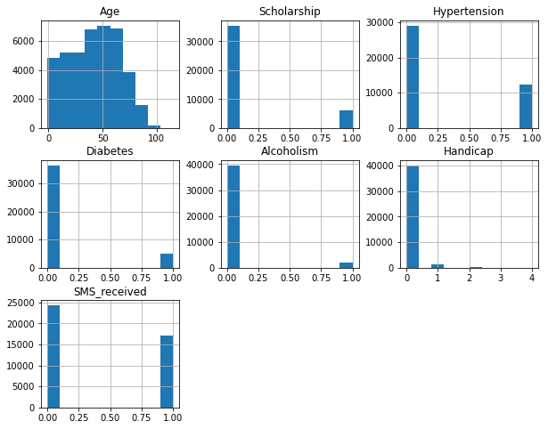

```python
df.hist(figsize=(10,8));
```

The above illustrations show the various distribution for various variables in the dataset.

### Research Question 1 (Does having a welfare program(scholarship) affect the tendency of a patient to show up for their appointment?

Looking into the correlation between the number of patinets that showed up for their medical appointments and the number of patients signed up to the welfare program (scholarships).

Firstly, lets look into the number of patients that showed up for their appoinments against those that did not.

The following code blocks will help analyze that;

```python
df['No-show'][0]
```

```
'No'
```

```python
type(df['No-show'][0])
```

```
str
```

```python
showed_up = df['No-show'] == "No"
```

```python
not_showed_up = df['No-show'] =="Yes"
```

```python
sum(df['No-show'] == "No" )
```

```
28680
```

```python
sum(showed_up)
```

```
28680
```

```python
number_showed_up = sum(df['No-show'] == "No" )
```

```python
sum(df['No-show'] =="Yes")
```

```
12873
```

```python
df['No-show'].value_counts()
```

```
No     28680
Yes    12873
Name: No-show, dtype: int64
```

The output of the above code blocks show the number of patients that showed up for their appointments i.e. data entries with 'No' under the No-show column as 28680. And the number of patients that did not show up for theor appoitnments i.e. data entries with 'Yes' under the No-show column as 12873.

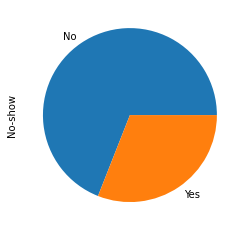

```python
df['No-show'].value_counts().plot(kind='pie');
```

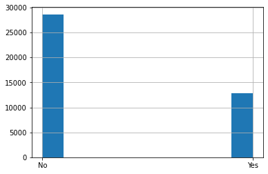

```python
df['No-show'].hist()
```

The above code block and output show a plot/distribution of the patients that attended their appointmnets and those that did not. We can see that ultimately, alot more patients showed up for their medical appointments.

```python
df['Scholarship'].value_counts()
```

```
0    35440
1     6113
Name: Scholarship, dtype: int64
```

```python
def group_data(lists):
    "Groups data, accepts list of columns as input"
    return df.groupby(lists).size()
```

The above code block creates a group data function that categorizes two columns of data. This function is used to categorize various columns of the dataset in the project.

```python
group_data(['Scholarship', 'No-show'])
```

```
Scholarship  No-show
0            No         24424
             Yes        11016
1            No          4256
             Yes         1857
dtype: int64
```

The first of the above code block cells is used to obtain the stats of patients with scholarships. Then the next code block creates a group data function that categorizes two columns of data. This function is used to categorize various columns of the dataset in the project. The code block is used to obtain the number of patients with or without scholarships, who did or did not show up for their medical appointments.

The output shows that of the 35440 patients without scholarships, 24424 patients showed up for their appointments and 11016 did not. Also, of the 6113 patients with scholarships, 4256 patients showed up for their appointments and 1857 did not.

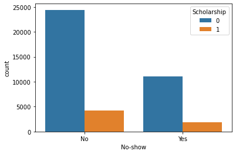

```python
import seaborn as sns
sns.countplot(x='No-show', hue='Scholarship', data=df)
```

Using the seaborn package, a distribution plot showing the number of patients with or without scholarships, who did or did not show up for their medical appointments.

The plot distribution shows that a realtively small amount of patients that showed up have scholarships. Also the same is noticed for patients that did not show up, as a little amount of them have scholarships. In general, a small proportion of the patients have scholarships. A strong trend is not determined from this investigation.

### Research Question 2 (Does a follow up sms notification affect the tendency of a patient to show up for their appointment?)

Looking into the correlation between the number of patinets that showed up for their medical appointments and if the patients received an SMS notification for their medical appointment.

Firstly, lets look into the number of patients that received SMS notifications for their appoinments against those that did not. And also the number of patients that showed up for their appointments and those that did not.

The following code blocks will help analyze that

```python
df['No-show'].value_counts()
```

```
No     28680
Yes    12873
Name: No-show, dtype: int64
```

```python
df['SMS_received'].value_counts()
```

```
0    24383
1    17170
Name: SMS_received, dtype: int64
```

The above code block output shows the number of patients that received SMS notifications as 17170 and those that did not receive SMS notofications as 24383.

```python
group_data(['SMS_received', 'No-show'])
```

```
SMS_received  No-show
0             No         17407
              Yes         6976
1             No         11273
              Yes         5897
dtype: int64
```

The above code block output shows the stats of patients that did and did not received SMS notifications, and also those who did or did not show up for their medical appointments.

The output shows that of the 17407 patients did not receive SMS notifications, but showed up for their appointments. Also, 6976 of the 24383 patients that did not receive SMS notifications did not show up. Furthermore, of the 17170 patients that received SMS notifications, 11273 patients showed up and 5897 did not attend their appointments.

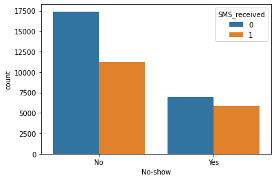

```python
sns.countplot(x='No-show', hue='SMS_received', data=df);
```

The above code block output shows the plot distribution of the amount of patients that showed up or did not showed with those that did or did not reeceive notifications.

### Research Question 3 (Does the neighbourhood of a patient affect the tendency of a patient to show up for their appointment?)

Looking into the correlation between the number of patinets that showed up for their medical appointments and the neighbourhood of the patient.

Firstly, lets look into the number of patients that live in the didfferent neighbourhoods. And also the number of patients that showed up for their appointments and those that did not.

The following code blocks will help analyze that

```python
df['Neighbourhood'].value_counts()
```

```
ITARARÉ                        1155
SANTA MARTHA                   1130
RESISTÊNCIA                    1111
JARDIM CAMBURI                 1105
TABUAZEIRO                     1080
                               ...
ILHA DO BOI                      23
ILHA DO FRADE                     7
AEROPORTO                         7
ILHAS OCEÂNICAS DE TRINDADE       2
PARQUE INDUSTRIAL                 1
Name: Neighbourhood, Length: 81, dtype: int64
```

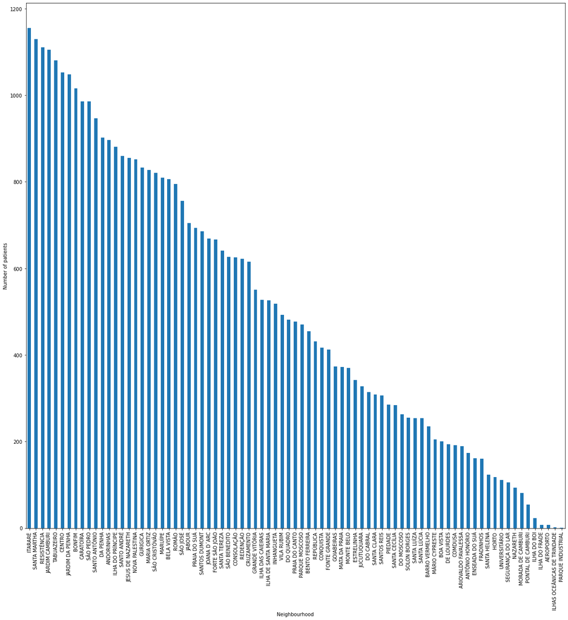

```python
ax = df['Neighbourhood'].value_counts().plot(kind='bar' , figsize = (20,20))
ax.set_xlabel('Neighbourhood')
ax.set_ylabel('Number of patients')
```

The above code block outputs show that stats for the patients that live across various neighbourhoods.

```python
group_data(['Neighbourhood', 'No-show'])
```

```
Neighbourhood    No-show
AEROPORTO        No           6
                 Yes          1
ANDORINHAS       No         592
                 Yes        304
ANTÔNIO HONÓRIO  No         136
                           ...
TABUAZEIRO       Yes        337
UNIVERSITÁRIO    No          88
                 Yes         23
VILA RUBIM       No         373
                 Yes        119
Length: 160, dtype: int64
```

### Research Question 4 (How does nature of the patient affliction of patinets affect the tendency of a patient to show up for their appointment?)

Looking into the correlation between the number of patinets that showed up for their medical appointments and the nature of affliction of the patient, i.e either hypertension, diabetes, alcoholism or handicap.

Firstly, lets look into the number of patients that are affected by each of those conditions. And also the number of patients that showed up for their appointments and those that did not.

The following code blocks will help analyze that

```python
sum(df['Hypertension'] == 0)
```

```
29123
```

The above code block shows the number of non-hypertensive patients, i.e. 29123 of the 41553 patients are non-hypertensive.

```python
sum(df['Hypertension'] == 1)
```

```
12430
```

The above code block shows the number of hypertensive patients, i.e. 12430 of the 41553 patients are hypertensive.

```python
sum(df['Diabetes'] == 0)
```

```
36455
```

The above code block shows the number of non-diabetic patients, i.e. 36455 of the 41553 patients are non-Diabetic.

```python
sum(df['Diabetes'] == 1)
```

```
5098
```

The above code block shows the number of diabetic patients, i.e. 5098 of the 41553 patients are Diabetic.

```python
sum(df['Alcoholism'] == 0)
```

```
39569
```

The above code block shows the number of non-alcoholic patients, i.e. 39569 of the 41553 patients are non-alcoholics.

```python
sum(df['Alcoholism'] == 1)
```

```
1984
```

The above code block shows the number of alcoholic patients, i.e. 1984 of the 41553 patients are alcoholics.

```python
sum(df['Handicap'] == 0)
```

```
40078
```

The above code block shows the number of non-handicap patients, i.e. 40078 of the 41553 patients are non-handicap.

```python
sum(df['Handicap'] != 0)
```

```
1475
```

The above code block shows the number of handicap patients, i.e. 1475 of the 41553 patients are handicap.

The code block was written in that manner because there a different values for handicap patients (1,2,3,4) depending on their conditions.

```python
sum(df['Handicap'] == 1)
```

```
1332
```

```python
sum(df['Handicap'] == 2)
```

```
131
```

```python
sum(df['Handicap'] == 3)
```

```
9
```

```python
sum(df['Handicap'] == 4)
```

```
3
```

The above code blocks show the number of handicap patients for each of the handicap conditions.

```python
group_data(['Hypertension', 'No-show'])
```

```
Hypertension  No-show
0             No         19274
              Yes         9849
1             No          9406
              Yes         3024
dtype: int64
```

The above output shows that of the 12430 hypertensive patients, 9406 patients showed up for their medical appointments.

```python
group_data(['Diabetes', 'No-show'])
```

```
Diabetes  No-show
0         No         24786
          Yes        11669
1         No          3894
          Yes         1204
dtype: int64
```

The above output shows that of the 5098 Diabetic patients, 3894 patients showed up for their medical appointments.

```python
group_data(['Alcoholism', 'No-show'])
```

```
Alcoholism  No-show
0           No         27266
            Yes        12303
1           No          1414
            Yes          570
dtype: int64
```

The above output shows that of the 1984 alcoholic patients, 1414 patients showed up for their medical appointments.

```python
group_data(['Handicap', 'No-show'])
```

```
Handicap  No-show
0         No         27506
          Yes        12572
1         No          1064
          Yes          268
2         No           102
          Yes           29
3         No             6
          Yes            3
4         No             2
          Yes            1
dtype: int64
```

The above output shows that of the 1475 Handicap patients, the following number of patients showed up for their medical appointments:

1064 patients of the 1332 with handicap condition 1 showed up. 102 patients of the 131 with handicap condition 2 showed up. 6 patients of the 9 with handicap condition 3 showed up. 2 patients of the 3 with handicap condition 4 showed up.

## References

- https://stackoverflow.com/questions/58453479/possible-to-plot-subset-of-column-based-on-unique-value-in-pandas
- https://stackoverflow.com/questions/58773477/creating-a-scatterplot-of-subsets-of-a-dataframe -https://stackoverflow.com/questions/41256648/select-multiple-ranges-of-columns-in-pandas-dataframe -https://stackoverflow.com/questions/48545076/selecting-multiple-dataframe-columns-by-position-in-pandas -https://stackoverflow.com/questions/16683701/in-pandas-how-to-get-the-index-of-a-known-value -https://classroom.udacity.com/nanodegrees/nd002-alg-t2/parts/cd0000/modules/306f0239-bb80-45c6-bf45-37ee745a63d6/lessons/ls0522/concepts/a39b2376-5af1-4968-a308-32ea60e39e1b -https://classroom.udacity.com/nanodegrees/nd002-alg-t2/parts/cd0000/modules/306f0239-bb80-45c6-bf45-37ee745a63d6/lessons/ls0526/concepts/f41d3e13-9bbc-45a7-8e7e-14f9e5ba1607 -https://stackoverflow.com/questions/12444716/how-do-i-set-the-figure-title-and-axes-labels-font-size-in-matplotlib?rq=1 -https://stackoverflow.com/questions/28931224/how-to-add-value-labels-on-a-bar-chart